# AEI Housing Assessment

## Data Profile

I used `PropertyID` as the join key. It appears in most pairwise matches the same `PropertyID` appears in both datasets more than assessor’s parcel number.

| Left | Right | Left rows | Right rows | Left distinct keys | Right distinct keys | Shared keys |
| --- | --- | --- | --- | --- | --- | --- |
| assessor | deed | 154,839 | 3,584 | 154,839 | 2,277 | 2,246 |
| assessor | avm | 154,839 | 116,303 | 154,839 | 116,303 | 116,303 |
| assessor | assessor_month | 154,839 | 4,875 | 154,839 | 4,875 | 4,875 |
| deed | avm | 3,584 | 116,303 | 2,277 | 116,303 | 1,704 |
| deed | assessor_month | 3,584 | 4,875 | 2,277 | 4,875 | 2,235 |
| avm | assessor_month | 116,303 | 4,875 | 116,303 | 4,875 | 3,943 |

Deed data has non-unique `PropertyID`. I presume this is because some properties are transacted multiple times.

| Transactions per PropertyID | Properties |
| --- | --- |
| 1 | 2,011 |
| 2 | 201 |
| 3 | 39 |
| 4 | 2 |
| 5 | 2 |
| 6 | 6 |
| 7 | 1 |
| 9 | 4 |
| 10 | 1 |
| 11 | 1 |
| 14 | 1 |
| 15 | 2 |
| 16 | 1 |
| 18 | 2 |
| 21 | 1 |
| 23 | 1 |
| 796 | 1 |

It looks like the monthly data contains only a subset of properties in the annual file.

| Metric | Count |
| --- | --- |
| Annual assessor properties | 154,839 |
| Monthly assessor properties | 4,875 |
| In both | 4,875 |
| Only in annual | 149,964 |
| Only in monthly | 0 |

### Data quality issues

#### There are some properties being transacted that are not in the assessor dataset

| Metric | Count |
| --- | --- |
| Deed properties | 2,277 |
| Matched to annual assessor | 2,246 |
| Matched to monthly assessor | 2,235 |
| Not in annual assessor | 31 |
| Not in monthly assessor | 42 |

#### Automated valuation model (AVM) estimates in the assessor data does not match that in the AVM data

| Field | Compared | Different | Pct different | Mean absolute error |
| --- | --- | --- | --- | --- |
| AVM value | 105,268 | 105,268 | 100.0% | 74,494.75 |
| Low value | 105,268 | 105,268 | 100.0% | 95,209.24 |
| High value | 105,268 | 105,268 | 100.0% | 90,748.3 |
| Confidence score | 105,268 | 103,455 | 98.3% | 16.18 |
| Standard deviation | 105,268 | 105,268 | 100.0% | 9.67 |

#### Less than 5% of assessor annual data matches to deed

| Metric | Value |
| --- | --- |
| Annual assessor rows | 154,839 |
| With current transaction ID | 95,920 |
| Current transaction matched to deed | 400 |
| Current transaction match rate | 0.4% |
| With previous transaction ID | 53,756 |
| Previous transaction matched to deed | 10 |
| Previous transaction match rate | 0.0% |

## Product

I was interested in how well the AVM predicts the sale price reported in the deed data, so the following is the mean absolute error of AVM compared to the sale price. Note that this matches both the deed and AVM datasets to only the monthly assessor data, since that merged better with the deed data (about 1/3 of rows).

| Metric | Value |
| --- | --- |
| Properties compared | 1,255 |
| Mean absolute error | $106,638 |
| Mean absolute error (% of median sale price) | 31.4% |
| Mean bias | $63,970 |
| Within +/- $100,000 | 910 |
| Within +/- $100,000 (%) | 72.5% |

It looks the frequency of the deviation is slightly right-skewed, but it looks like three-quarters of values fall within +/- $100,000.

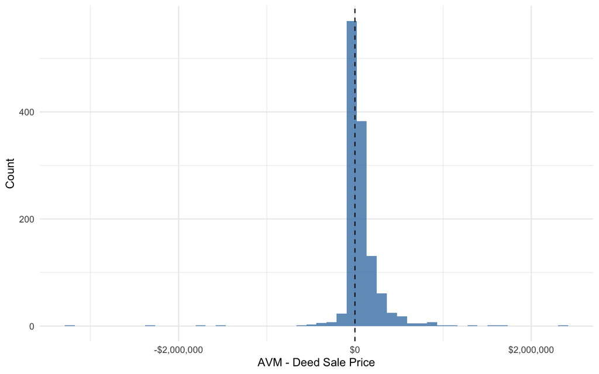

## Memo

I’m not sure where the AVM data is sourced, but I think it’s important to produce predictions of price that are accurate. To be honest, the choice of analysis was also a function of time and the surface-level familiarity I had developed over an hour of looking at the data.

The next step I would’ve done would be to fit a decision tree with an algorithm like random forest on the assesor dataset.